# Module3_Assignment_Ananya

Ananya Sharma

30/01/2022

- Descriptive Analytics: Summary
- Corrplot for Continuous data
- Regression Analysis
- Checking Outliers and removing them - Part B
- Check the Regression Model for Multi-Collinearity
- Conclusion and Analysis
- References

```r
# Read the file
Ames_Dataset<-read.csv("AmesHousing.csv")
```

## Descriptive Analytics: Summary

## Corrplot for Continuous data

- This graph has been taken from the first assignment for understanding the correlation amongst the variables in the data set

```r
 #Reference- Assignment 1(self)

c<-subset(Ames_df,select=c(Screen.Porch,Overall.Qual,Lot.Area,Fireplaces,Gr.Liv.Area,SalePrice,Year.Built))
MyCorr1<-as.data.frame(cor(c))  #Converting to a data frame

cor(MyCorr1)
```

```
             Screen.Porch Overall.Qual     Lot.Area   Fireplaces Gr.Liv.Area
Screen.Porch    1.0000000   -0.5877221 -0.268491483 -0.228911072 -0.48190715
Overall.Qual   -0.5877221    1.0000000 -0.433266192  0.166088038  0.59314453
Lot.Area       -0.2684915   -0.4332662  1.000000000 -0.009641972 -0.01029306
Fireplaces     -0.2289111    0.1660880 -0.009641972  1.000000000  0.38078153
Gr.Liv.Area    -0.4819071    0.5931445 -0.010293064  0.380781526  1.00000000
SalePrice      -0.6161196    0.9191334 -0.255050484  0.253828277  0.75635436
Year.Built     -0.5802653    0.7306693 -0.481776031 -0.176527704  0.11619357
              SalePrice Year.Built
Screen.Porch -0.6161196 -0.5802653
Overall.Qual  0.9191334  0.7306693
Lot.Area     -0.2550505 -0.4817760
Fireplaces    0.2538283 -0.1765277
Gr.Liv.Area   0.7563544  0.1161936
SalePrice     1.0000000  0.6134301
Year.Built    0.6134301  1.0000000
```

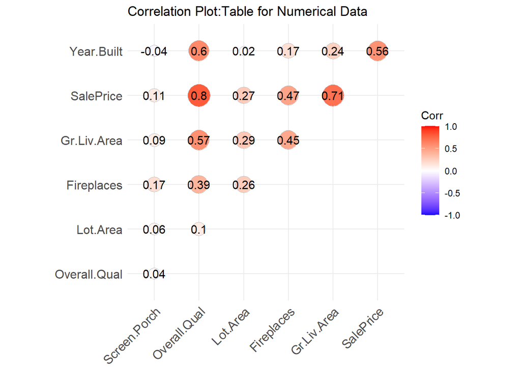

```r
ggcorrplot(cor(c),method = "circle",
                       title = "Correlation Plot:Table for Numerical Data"
                       ,type = "upper",
                       lab = TRUE)
```

……………….

```r
Ames_corr = subset(Ames_df, select=c(Yr.Sold,SalePrice,Year.Built,Garage.Area,Lot.Frontage,Yr.Sold,Wood.Deck.SF,Pool.Area,Kitchen.AbvGr,TotRms.AbvGrd,Lot.Area,MS.SubClass,Bedroom.AbvGr,Misc.Val,Gr.Liv.Area))


X1<-na.omit(Ames_corr)     # removing NA Values

des_stat_corr <- psych::describe(X1)
des_stat_corr
```

```
              vars    n      mean       sd median   trimmed      mad   min
Yr.Sold          1 2439   2007.79     1.32   2008   2007.73     1.48  2006
SalePrice        2 2439 180111.71 83500.45 157500 168548.13 55597.50 12789
Year.Built       3 2439   1970.54    31.53   1972   1973.41    40.03  1872
Garage.Area      4 2439    469.30   222.03    478    465.06   204.60     0
Lot.Frontage     5 2439     69.23    23.37     68     68.36    17.79    21
Yr.Sold.1        6 2439   2007.79     1.32   2008   2007.73     1.48  2006
Wood.Deck.SF     7 2439     88.91   120.67      0     67.33     0.00     0
Pool.Area        8 2439      2.39    36.05      0      0.00     0.00     0
Kitchen.AbvGr    9 2439      1.05     0.22      1      1.00     0.00     0
TotRms.AbvGrd   10 2439      6.44     1.58      6      6.32     1.48     2
Lot.Area        11 2439   9709.79  6425.43   9250   9276.18  2944.44  1300
MS.SubClass     12 2439     57.77    43.61     50     49.81    44.48    20
Bedroom.AbvGr   13 2439      2.84     0.82      3      2.81     0.00     0
Misc.Val        14 2439     44.15   501.43      0      0.00     0.00     0
Gr.Liv.Area     15 2439   1488.84   506.26   1433   1439.94   446.26   334
                 max  range  skew kurtosis      se
Yr.Sold         2010      4  0.14    -1.16    0.03
SalePrice     755000 742211  1.78     4.98 1690.76
Year.Built      2010    138 -0.55    -0.67    0.64
Garage.Area     1488   1488  0.24     0.72    4.50
Lot.Frontage     313    292  1.50    11.20    0.47
Yr.Sold.1       2010      4  0.14    -1.16    0.03
Wood.Deck.SF     870    870  1.62     3.61    2.44
Pool.Area        800    800 16.08   270.70    0.73
Kitchen.AbvGr      3      3  4.28    19.20    0.00
TotRms.AbvGrd     15     13  0.79     1.21    0.03
Lot.Area      215245 213945 15.05   437.53  130.11
MS.SubClass      190    170  1.37     1.32    0.88
Bedroom.AbvGr      8      8  0.35     1.90    0.02
Misc.Val       17000  17000 24.16   708.49   10.15
Gr.Liv.Area     5642   5308  1.39     4.95   10.25
```

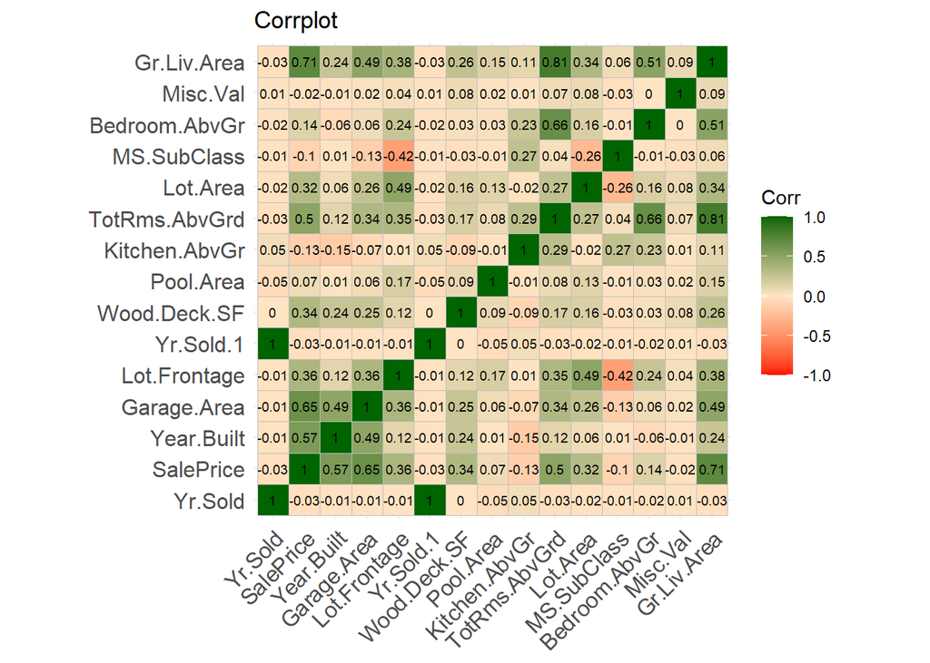

```r
corplotting <- cor(X1)

ggcorrplot((round(corplotting,2)),
           colors = c("red", "bisque", "darkgreen"),lab = TRUE,lab_size =2.5) +
  ggtitle("Corrplot ")
```

- The above corr plot depicts that Sale Price has a medium correlation with Garage Area(0.65)
- The above corr plot has a weak relation with the Kitchen Above Ground(-0.13)
- The corr plot sets a base which helps us to analyse which variables we can consider for our study ahead for the regression Analysis.

## Regression Analysis

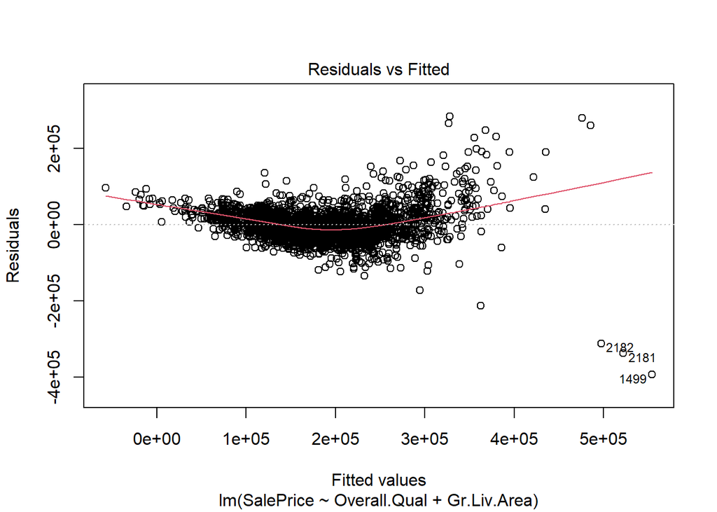

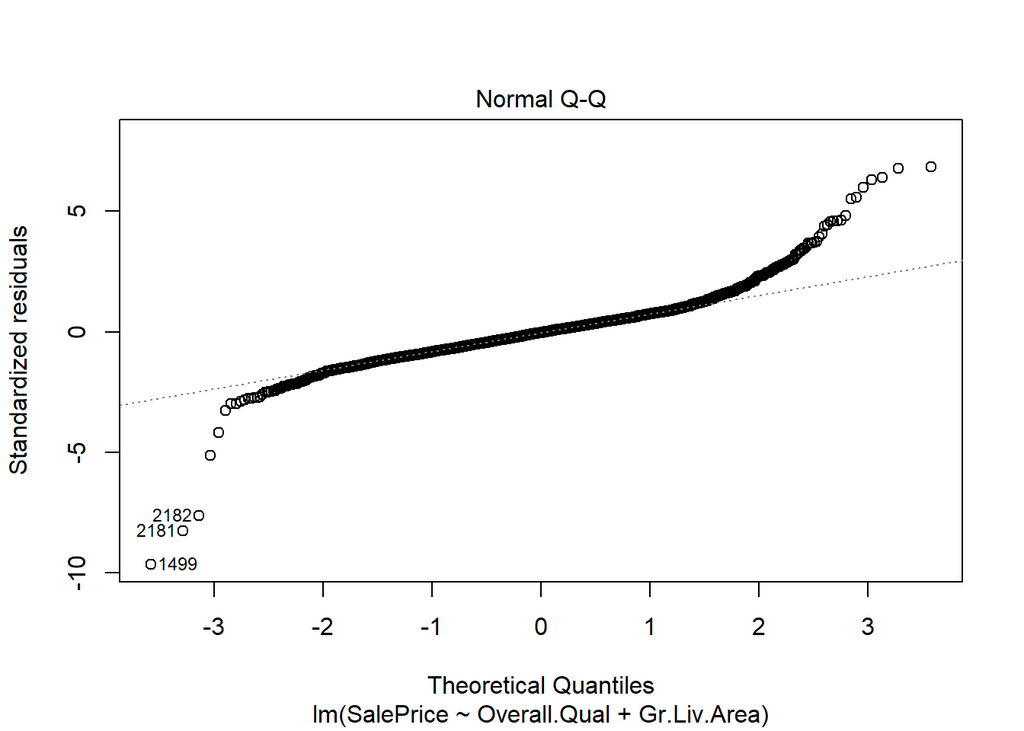

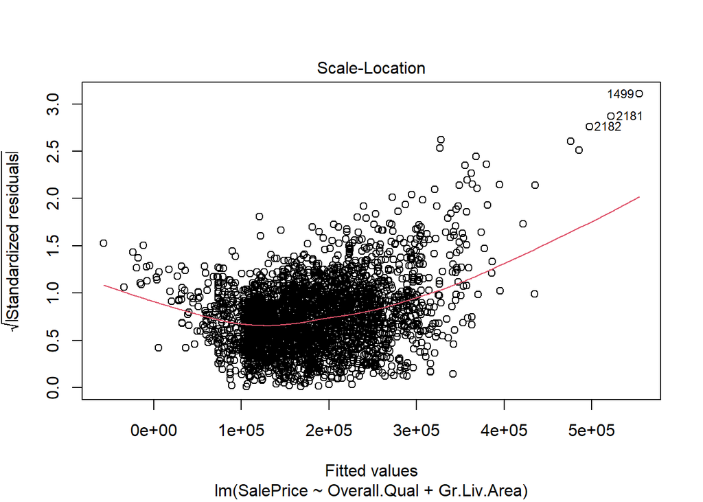

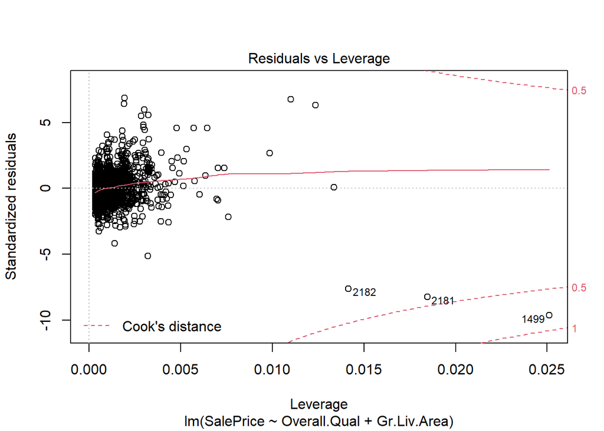

```r
# Variables with the highest correlations.
# Sales prices and different ranges of correlations
# High correlation of Sale Price with Greater Living Area and Overall Quality
library(stats)
z <- lm(SalePrice ~ Overall.Qual+Gr.Liv.Area, data = Ames_df)

plot(z)
```

```r
summary(z)                # To summarise the regression model
```

```
Call:
lm(formula = SalePrice ~ Overall.Qual + Gr.Liv.Area, data = Ames_df)

Residuals:
    Min      1Q  Median      3Q     Max
-393985  -23302   -1227   19949  283509

Coefficients:
               Estimate Std. Error t value Pr(>|t|)
(Intercept)  -1.099e+05  3.421e+03  -32.13   <2e-16 ***
Overall.Qual  3.324e+04  6.596e+02   50.40   <2e-16 ***
Gr.Liv.Area   5.875e+01  1.841e+00   31.91   <2e-16 ***
---
Signif. codes:  0 '***' 0.001 '**' 0.01 '*' 0.05 '.' 0.1 ' ' 1

Residual standard error: 41370 on 2927 degrees of freedom
Multiple R-squared:  0.732, Adjusted R-squared:  0.7319
F-statistic:  3998 on 2 and 2927 DF,  p-value: < 2.2e-16
```

```r
#Residu<-resid(z)              # to access the Residuals for sale Price and Over All Quality of the house

coef(z)             # the coefficient of Sale Price and Overall Quality is 45251
```

```
  (Intercept)  Overall.Qual   Gr.Liv.Area
-109919.15551   33241.40006      58.75403
```

- The goodness of fit of a regression model is determined by R-square. As a result, a greater R-square shows that the model is well-fitting, whereas a lower R-squared suggests that the model is not well-fitting.
- We have used Overall Quality and Gr Living Area as the explanatory variables for our first analysis.Both are having high correlation with the sales price.
- The F statistic is 3998 on 2 and 2927 Degrees of Freedom
- The R Squared value is 0.732 and Adjusted R Squared Value 0.7319. R Square determines the degree of variation of the output variables.However, R squared is not a formal test.
- Any value above 0.7 is a good R Square Value for estimating that the independent variables can be considered for studying the effect on the dependent variable, however, any further increments can greatly increase the R Square drastically.
- The F statistic is a ratio of the two variances. F test can represent the dispersion of the data from the mean.
- Here the overall p-value: < 2.2e-16 , that means that at least one independent value is associated with the output variable. If we take more than one independent variable the output won’t be biased.
- `Interpretating a QQ Plot:` The line plotted here is deviating at the ends.QQ plot is able to tell if the data is normally distributed or not.
- `Residual vs Fitted Plot:` This plot tells us that the linearity is violated. The spread of the residuals tends to be increasing progressively towards the right hand side of the x axis.
- `The standardised Residuals vs Fitted Model:` This graph shows that the residuals increase with the predictor variables.The graph needs the predictor to be fitted with logarithmic function for a better interpretation.

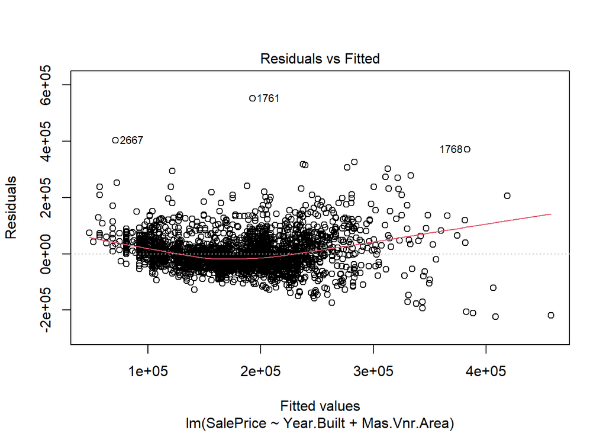

Figure: Regression Analysis with low correlation

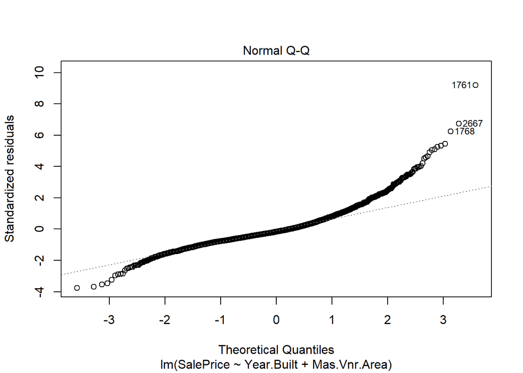

Figure: Regression Analysis with low correlation

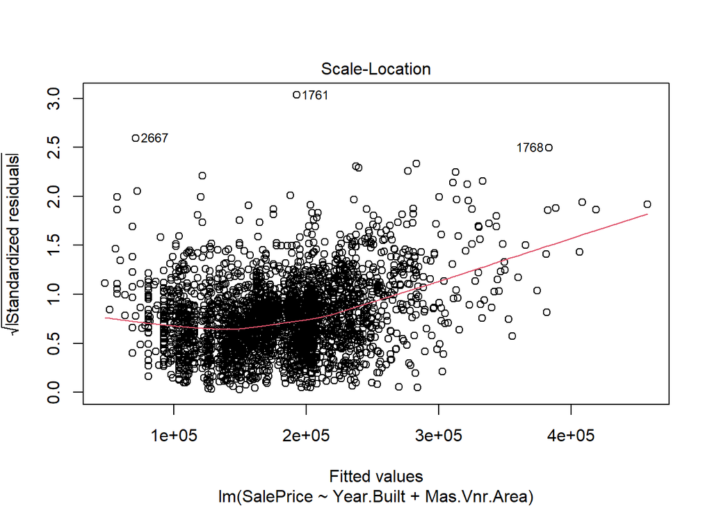

Figure: Regression Analysis with low correlation

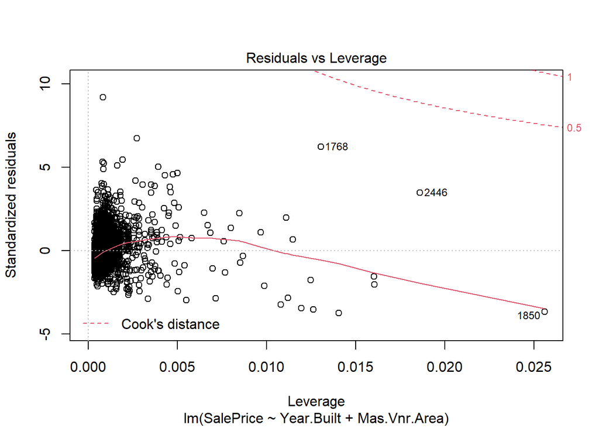

Figure: Regression Analysis with low correlation

```r
#Variables with the lowest correlation

b <- lm(SalePrice ~ Year.Built+Mas.Vnr.Area, data = Ames_df)

plot(b)              #This plot takes care of QQ Plot and residual Plot
```

```r
summary(b)                # To summarise the regression model
```

```
Call:
lm(formula = SalePrice ~ Year.Built + Mas.Vnr.Area, data = Ames_df)

Residuals:
    Min      1Q  Median      3Q     Max
-224476  -34852  -10136   24193  552345

Coefficients:
               Estimate Std. Error t value Pr(>|t|)
(Intercept)  -2.138e+06  7.627e+04  -28.03   <2e-16 ***
Year.Built    1.168e+03  3.880e+01   30.09   <2e-16 ***
Mas.Vnr.Area  1.648e+02  6.546e+00   25.17   <2e-16 ***
---
Signif. codes:  0 '***' 0.001 '**' 0.01 '*' 0.05 '.' 0.1 ' ' 1

Residual standard error: 60030 on 2904 degrees of freedom
  (23 observations deleted due to missingness)
Multiple R-squared:  0.4347,    Adjusted R-squared:  0.4343
F-statistic:  1116 on 2 and 2904 DF,  p-value: < 2.2e-16
```

```r
#Residu<-resid(b)      # to access the Residuals for sale Price and Over All Quality of the house

coef(b)             # the coefficient of Sale Price and Overall Quality is 45251
```

```
  (Intercept)    Year.Built  Mas.Vnr.Area
-2137831.2609     1167.5782      164.7549
```

```r
#Plot for highest Magnitude of Coefficient

require(stats)
par(mfcol= c(2,2))
# Equation to find out the intercept and the slope of the line

reg1<-lm(SalePrice ~ Gr.Liv.Area, data = Ames_df)   # Ground Floor Liv area has a high coef magnitude
summary(reg1)
```

```
Call:
lm(formula = SalePrice ~ Gr.Liv.Area, data = Ames_df)

Residuals:
    Min      1Q  Median      3Q     Max
-483467  -30219   -1966   22728  334323

Coefficients:
             Estimate Std. Error t value Pr(>|t|)
(Intercept) 13289.634   3269.703   4.064 4.94e-05 ***
Gr.Liv.Area   111.694      2.066  54.061  < 2e-16 ***
---
Signif. codes:  0 '***' 0.001 '**' 0.01 '*' 0.05 '.' 0.1 ' ' 1

Residual standard error: 56520 on 2928 degrees of freedom
Multiple R-squared:  0.4995,    Adjusted R-squared:  0.4994
F-statistic:  2923 on 1 and 2928 DF,  p-value: < 2.2e-16
```

```r
res1 <- residuals(reg1)


#Plotting regression line with highest T statistic
plot(fitted(reg1),res1,
     col='red', pch=12, cex=.5,
     main="Sale price vs Ground floor living area",
     ylab="Sale Price", xlab="Ground Floor Living area") +
  abline( 0,0)
```

```
integer(0)
```

```r
#Plot between Highest T statistic

reg2<-lm(SalePrice ~ Overall.Qual, data = Ames_df) # Ground Floor Liv area has a high coef magnitude
summary(reg2)
```

```
Call:
lm(formula = SalePrice ~ Overall.Qual, data = Ames_df)

Residuals:
    Min      1Q  Median      3Q     Max
-197507  -29254   -2283   21658  397493

Coefficients:
             Estimate Std. Error t value Pr(>|t|)
(Intercept)  -95003.6     3933.8  -24.15   <2e-16 ***
Overall.Qual  45251.0      628.8   71.96   <2e-16 ***
---
Signif. codes:  0 '***' 0.001 '**' 0.01 '*' 0.05 '.' 0.1 ' ' 1

Residual standard error: 48020 on 2928 degrees of freedom
Multiple R-squared:  0.6388,    Adjusted R-squared:  0.6387
F-statistic:  5179 on 1 and 2928 DF,  p-value: < 2.2e-16
```

```r
res2 <- residuals(reg2)
plot(fitted(reg2),res2,col='red', pch=12, cex=.5,
     main="Sale price and Over All Quality",
     ylab="Sale Price", xlab="Over All Quality") +
  abline(0,0)
```

```
integer(0)
```

```r
# Plot between the lowest Coefficient

reg3<-lm(SalePrice ~ Year.Built, data = Ames_df)
summary(reg3)
```

```
Call:
lm(formula = SalePrice ~ Year.Built, data = Ames_df)

Residuals:
    Min      1Q  Median      3Q     Max
-147394  -41227  -14502   23093  540805

Coefficients:
              Estimate Std. Error t value Pr(>|t|)
(Intercept) -2.727e+06  7.983e+04  -34.16   <2e-16 ***
Year.Built   1.475e+03  4.049e+01   36.43   <2e-16 ***
---
Signif. codes:  0 '***' 0.001 '**' 0.01 '*' 0.05 '.' 0.1 ' ' 1

Residual standard error: 66280 on 2928 degrees of freedom
Multiple R-squared:  0.3118,    Adjusted R-squared:  0.3116
F-statistic:  1327 on 1 and 2928 DF,  p-value: < 2.2e-16
```

```r
res3 <- residuals(reg3)
plot(fitted(reg3),res3,
     col='red', pch=12, cex=.5,
     main="Sale price vs Year Built",
     ylab="Sale Price", xlab="Year Built") +
  abline(0,0)
```

```
integer(0)
```

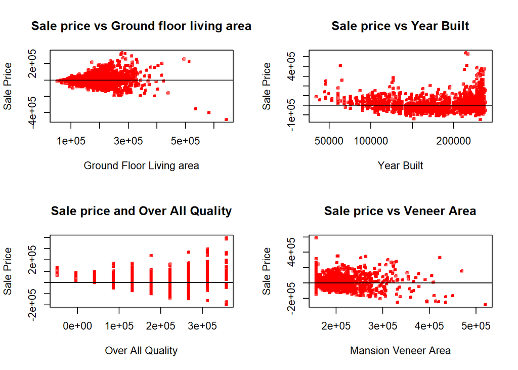

```
integer(0)
```

```r
#Plot Between the lowest t statistic


###
Model_reg4<-lm(SalePrice ~ Mas.Vnr.Area, data = Ames_df)
res4<-residuals(Model_reg4)


plot(fitted(Model_reg4),res4,
     col='red', pch=12, cex=.5,
     main="Sale price vs Veneer Area",
     ylab="Sale Price", xlab="Mansion Veneer Area") +
  abline(0,0)
```

## Checking Outliers and removing them - Part B

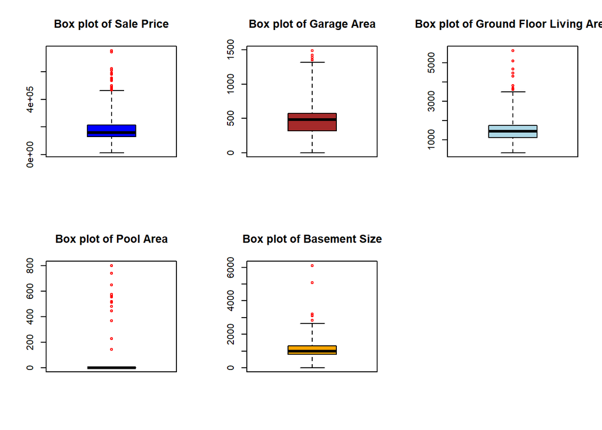

```r
# Create a boxplot of the dataset - Identify five outliers
par(mfrow = c(2,3))
Outlier_Value1 = boxplot(Ames_df$SalePrice,main="Box plot of Sale Price", range=3,outcol="red",col="blue")$out
Outlier_Value2 = boxplot(Ames_df$Garage.Area,main="Box plot of Garage Area", range=3,outcol="red",col="brown")$out
Outlier_Value3 = boxplot(Ames_df$Gr.Liv.Area,main="Box plot of Ground Floor Living Area", range=3,outcol="red",col="lightblue")$out
Outlier_Value4 = boxplot(Ames_df$Pool.Area,main="Box plot of Pool Area", range=3,outcol="red",col="cyan")$out
Outlier_Value5 = boxplot(Ames_df$Total.Bsmt.SF,main="Box plot of Basement Size", range=3,outcol="red",col="orange")$out


# Removing the outliers

Remove_Val1 <- Ames_df$SalePrice[!Ames_df$SalePrice %in% boxplot.stats(Ames_df$SalePrice)$out]
Remove_Val2 <- Ames_df$Garage.Area[!Ames_df$Garage.Area %in% boxplot.stats(Ames_df$Garage.Area)$out]
Remove_Val3 <- Ames_df$Gr.Liv.Area[!Ames_df$Gr.Liv.Area %in% boxplot.stats(Ames_df$Gr.Liv.Area)$out]
Remove_Val4 <- Ames_df$Pool.Area[!Ames_df$Pool.Area %in% boxplot.stats(Ames_df$Pool.Area)$out]
Remove_Val5 <- Ames_df$Total.Bsmt.SF[!Ames_df$Total.Bsmt.SF %in% boxplot.stats(Ames_df$Total.Bsmt.SF)$out]

#boxplot(Remove_Val1)
#boxplot(Remove_Val2)
#boxplot(Remove_Val3)
#boxplot(Remove_Val4)
#boxplot(Remove_Val5)
```

## Check the Regression Model for Multi-Collinearity

```r
library(carData)
library(car)
Multi_col_check <- glm(SalePrice ~ Year.Built + Gr.Liv.Area + Garage.Area +
                       + Lot.Area,data = Ames_Dataset)
summary(Multi_col_check)
```

```
Call:
glm(formula = SalePrice ~ Year.Built + Gr.Liv.Area + Garage.Area +
    +Lot.Area, data = Ames_Dataset)

Deviance Residuals:
    Min       1Q   Median       3Q      Max
-495516   -23437    -3189    17522   301999

Coefficients:
              Estimate Std. Error t value Pr(>|t|)
(Intercept) -1.688e+06  5.968e+04 -28.290  < 2e-16 ***
Year.Built   8.644e+02  3.073e+01  28.125  < 2e-16 ***
Gr.Liv.Area  7.869e+01  1.879e+00  41.876  < 2e-16 ***
Garage.Area  8.447e+01  4.807e+00  17.571  < 2e-16 ***
Lot.Area     6.927e-01  1.084e-01   6.393 1.88e-10 ***
---
Signif. codes:  0 '***' 0.001 '**' 0.01 '*' 0.05 '.' 0.1 ' ' 1

(Dispersion parameter for gaussian family taken to be 1927258386)

    Null deviance: 1.8692e+13  on 2928  degrees of freedom
Residual deviance: 5.6353e+12  on 2924  degrees of freedom
  (1 observation deleted due to missingness)
AIC: 70939

Number of Fisher Scoring iterations: 2
```

```r
G<-summ(Multi_col_check, vifs = T)
G                           #Reading the summary for Multi collinearity for the select variables
```

```
MODEL INFO:
Observations: 2929 (1 missing obs. deleted)
Dependent Variable: SalePrice
Type: Linear regression

MODEL FIT:
χ²(4) = 13056340049507.49, p = 0.00
Pseudo-R² (Cragg-Uhler) = 0.70
Pseudo-R² (McFadden) = 0.05
AIC = 70939.30, BIC = 70975.19

Standard errors: MLE
-----------------------------------------------------------------
                           Est.       S.E.   t val.      p    VIF
----------------- ------------- ---------- -------- ------ ------
(Intercept)         -1688263.19   59676.40   -28.29   0.00
Year.Built               864.42      30.73    28.13   0.00   1.31
Gr.Liv.Area               78.69       1.88    41.88   0.00   1.37
Garage.Area               84.47       4.81    17.57   0.00   1.62
Lot.Area                   0.69       0.11     6.39   0.00   1.11
-----------------------------------------------------------------

Estimated dispersion parameter = 1927258386
```

```r
vif(Multi_col_check)
```

```
 Year.Built Gr.Liv.Area Garage.Area    Lot.Area
   1.312134    1.371321    1.623656    1.107901
```

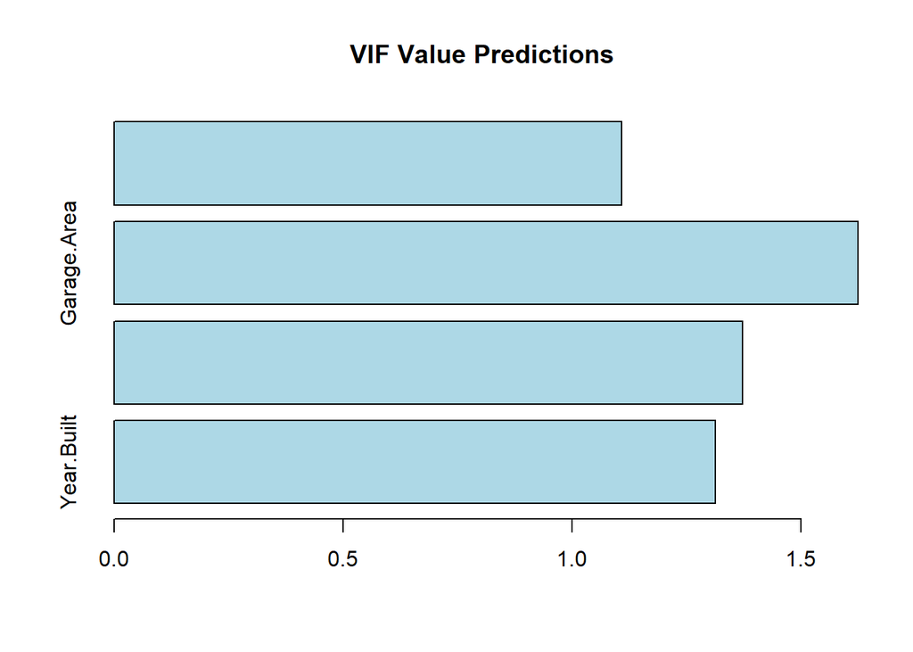

```
numeric(0)
```

```r
vif_values <- vif(Multi_col_check)

barplot(vif_values, main = "VIF Value Predictions", horiz = TRUE, col = "lightblue") +
  abline(v = 4, lwd = 3,lty = 3)   #Making a bar plot to understand the levels of multi collinearity
```

- Multi collinearity exists if the independent variables have a very high correlation.
- VIF greater than 5 or 10 indicates that there is a very high multi collinearity.
- VIF(Variance Inflation Function) function checks for multicollinearity
- A value of 1 tells that the variables don’t have much correlation, 1-5 shows medium correlation and >5 shows high correlation amongst the independent variables considered for regression analysis.

## Conclusion and Analysis

- The QQ plot is a measure to show if the variables are normally distributed or not.
- We can remove Multicollinearity making the variables standard. It is done by calculating the mean for each continuous independent variable and then subtracting the mean from all observed variables.

## References

- Residual Plot | R Tutorial. (2009). Copyright (C) 2009 - 2012 Chi Yau. All Rights Reserved.  
  http://www.r-tutor.com/elementary-statistics/simple-linear-regression/residual-plot
- GeeksforGeeks. (2020, July 14). Adding Straight Lines to a Plot in R Programming - abline() Function. https://www.geeksforgeeks.org/adding-straight-lines-to-a-plot-in-r-programming-abline-fun ction/
- Scatter Plots - R Base Graphs - Easy Guides - Wiki - STHDA. (2021). Http://Www.Sthda.Com/. http://www.sthda.com/english/wiki/scatter-plots-r-base-graphs
- Remove Outliers from Data Set in R (Example) | Find, Detect & Delete. (2021, January 18). Statistics Globe. https://statisticsglobe.com/remove-outliers-from-data-set-in-r
- Understand the F-statistic in Linear Regression. (2021). Https://Quantifyinghealth.Com/. https://quantifyinghealth.com/f-statistic-in-linear-regression/